# colocRedRibbon: a RedRibbon based colocalization of GWAS and eQTL.

# The colocRedRibbon object

The RedRibbon overlap p-value is given by

```r
rrc.dec$quadrants$whole$pvalue
```

```
#> [1] 2.621389e-41
```

and the overlapping variants are

```r
rrc.dec$data[rrc.dec$quadrants$whole$positions]$id
```

```
#>  [1] "rs10743152" "rs10770140" "rs10770141" "rs10770142" "rs10770143"
#>  [6] "rs10840495" "rs10840496" "rs10840500" "rs11042965" "rs11042966"
#> [11] "rs11042976" "rs11042978" "rs11564711" "rs4929964"  "rs4929965"
#> [16] "rs4929966"  "rs4930046"  "rs7115640"  "rs7119275"  "rs7128097"
#> [21] "rs72853903" "rs7482891"
```

The coloc structure contains

```r
rrc.dec$coloc
```

```
#> $bestSnp
#> [1] "rs4929965"
#>
#> $PP.H4.abf
#> PP.H4.abf
#> 0.9799012
#>
#> $SNP.PP.H4
#> [1] 0.2890225
#>
#> $ncredibleSet99
#> [1] 12
#>
#> $credibleSet99
#>  [1] "rs4929965"  "rs10770142" "rs4929964"  "rs7482891"  "rs10840496"
```

[output cut: 76 more lines]

## Plotting the level map

Co-localization results can be visualized using the helper function *ggRedRibbonColoc*. This function helps generate plots that illustrate the colocalization analysis. By evaluating the p-values of the overlap map, users can easily interpret the relationships between SNPs associated with an increased risk for disease and those responsible for gene expression variation.

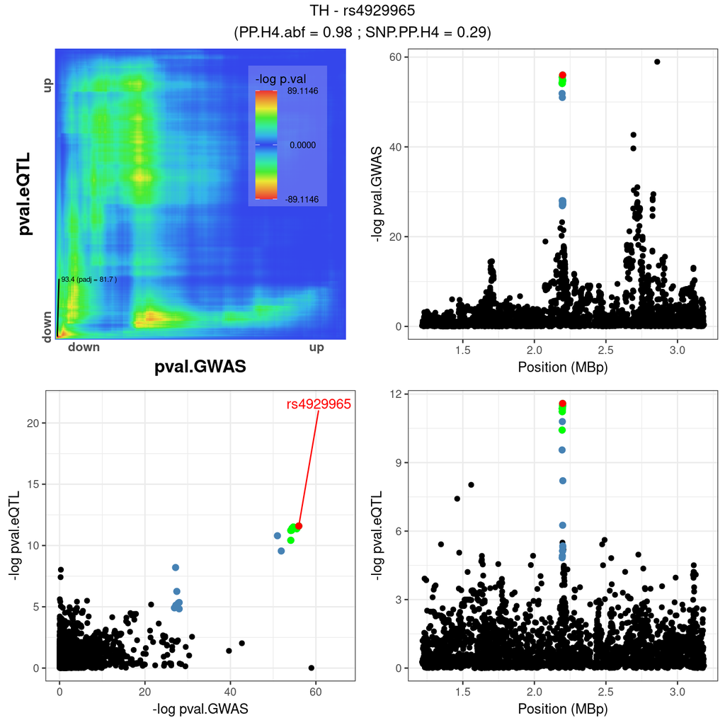

```r
gg <- ggRedRibbonColoc(rrc.dec, shortid = "TH")
gg
```

For additional optional parameters to customize the visualization of colocalization results please see the function documentation in R (with `?ggRedRibbonColoc`).

The gg variable contains a standard ggplot2 object, which can be modified and customized using the ggplot2 parameters in R.

```r
class(gg)
```

```
#> [1] "gg"     "ggplot"
```

## colocRedRibbon workflow

*colocRedRibbon* is a method designed to identify common causal candidates by examining the co-localization of GWAS and eQTL. This approach aims to pinpoint variants that are linked to both disease risk and variation in gene expression.

The method employs a two-step approach for shortlisting variants: - **Risk allele effect step:** In this step, variants are categorized into two distinct groups based on their direction of effect on gene expression, i.e., down- or upregulating. The upregulating variant set comprises the variants whose risk alleles increase gene expression, and the downregulating set risk alleles that decrease gene expression. Each of these variant sets is analyzed independently in subsequent steps. - **RedRibbon Overlap Step:** In this step, the RedRibbon rank-rank hypergeometric overlap method is applied on both GWAS and eQTL variants, which are ranked according to their P-values. This analysis examines the potential overlap between the two ranked lists. If a significant overlap is detected by RedRibbon, these shortlisted SNPs are further analyzed by the coloc package. If no significant overlap is found, the coloc method is still applied to the two effect sets without the preliminary overlap shortlisting.

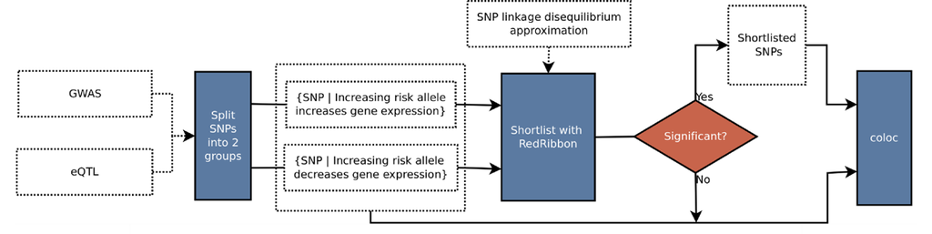

## IQR mode

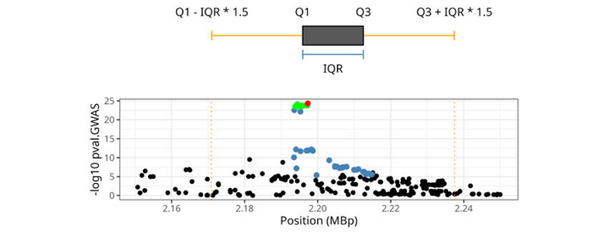

The IQR mode is activated by setting the `region.mode` parameter,

```r
## Run C. Wallace coloc()
rrcIQR.dec <- coloc(rrc.dec, region.mode = "IQR")
```

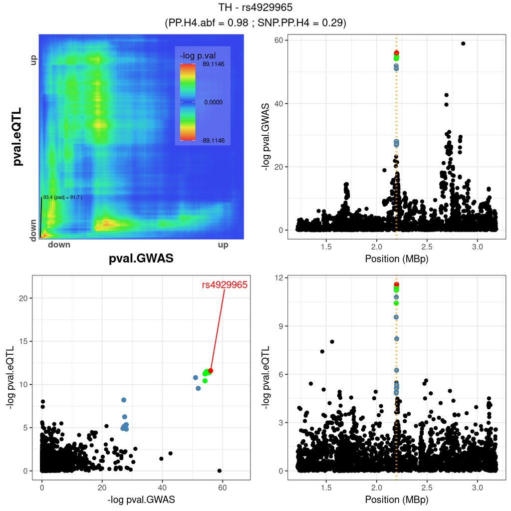

```r
gg <- ggRedRibbonColoc(rrcIQR.dec, shortid = "TH")
gg
```